# s01_read_vcf_to_r

started: AL13Aug2018  
last updated: AL20Sep2019

# summary

Read vcf to R (13,046 variants x 739 cases)  
Parse VEP  
Recode to additive  
Split allelic depth table  
Update rownames  
Update Multiallelic flag  
Split SIFT and Polyphen

# start section

```r
Sys.time()
```

```
## [1] "2019-09-20 15:49:20 BST"
```

```r
rm(list=ls())
graphics.off()

library(knitr)
library(vcfR) # for reading VCF
library(stringr) # for word (for VEP parsing)
library(tidyr) # for separate (for VEP parsing)
library(dplyr) # for renaming AC, AN and AF
base_folder="/Users/alexey/Documents/wecare/ampliseq/v05_ampliseq_only/s06_read_vcf_to_r"
opts_knit$set(root.dir = base_folder)
options(stringsAsFactors = F,
        warnPartialMatchArgs = T,
        warnPartialMatchAttr = T,
        warnPartialMatchDollar = T)

#options(error = browser()) # Type Q or c to exit, drop browser level
# https://support.rstudio.com/hc/en-us/articles/200713843?version=1.1.456&mode=desktop
# https://stackoverflow.com/questions/13052522/how-to-leave-the-r-browser-mode-in-the-console-window/13052588
```

# read vcfr

```r
# Source VCF
vcf_file="/Users/alexey/Documents/wecare/ampliseq/v04_ampliseq_nfe/s04_annotated_vcf/ampliseq_nfe.vcf"

# Read vcf to vcfR object
vcfr <- read.vcfR(vcf_file)
```

[output not shown]

```r
# Clean-up
rm(vcf_file)
```

# extract meta and fixed

```r
# Get data from header and fixed columns
meta_fix <- vcfR2tidy(vcfr, info_only=T)

# Get data frame with meta-information from vcf header
meta.df <- meta_fix$meta
dim(meta.df)
```

```
## [1] 87  5
```

```r
meta.df
```

```
## # A tibble: 87 x 5
##    Tag   ID              Number Type    Description
##    <chr> <chr>           <chr>  <chr>   <chr>
##  1 INFO  AC              A      Integer Allele count in genotypes, for each ALT allele, in the same order as listed
##  2 INFO  AF              A      Float   Allele Frequency, for each ALT allele, in the same order as listed
##  3 INFO  AN              1      Integer Total number of alleles in called genotypes
##  4 INFO  AS_FilterStatus A      String  Filter status for each allele, as assessed by ApplyRecalibration. Note that the VCF filter field will reflect the most lenient/sensitive status across all alleles.
##  5 INFO  AS_VQSLOD       A      String  For each alt allele, the log odds of being a true variant versus being false under the trained gaussian mixture model
##  6 INFO  AS_culprit      A      String  For each alt allele, the annotation which was the worst performing in the Gaussian mixture model, likely the reason why the variant was filtered out
##  7 INFO  BaseQRankSum    1      Float   Z-score from Wilcoxon rank sum test of Alt Vs. Ref base qualities
##  8 INFO  ClippingRankSum 1      Float   Z-score From Wilcoxon rank sum test of Alt vs. Ref number of hard clipped bases
##  9 INFO  DB              0      Flag    dbSNP Membership
## 10 INFO  DP              1      Integer Approximate read depth; some reads may have been filtered
## # … with 77 more rows
```

```r
# Get data frame with fixed columns (including parsed INFO, convert tibble to data-frame)
fixed.df <- as.data.frame(meta_fix$fix)
dim(fixed.df)
```

```
## [1] 13046    94
```

```r
colnames(fixed.df)
```

```
##  [1] "CHROM"                   "POS"                     "ID"                      "REF"                     "ALT"                     "QUAL"                    "FILTER"                  "AC"                      "AF"                      "AN"                      "AS_FilterStatus"         "AS_VQ…
## [39] "exac_non_TCGA.AC"        "exac_non_TCGA.AC_AFR"    "exac_non_TCGA.AC_AMR"    "exac_non_TCGA.AC_Adj"    "exac_non_TCGA.AC_EAS"    "exac_non_TCGA.AC_FEMALE" "exac_non_TCGA.AC_FIN"    "exac_non_TCGA.AC_Hemi"   "exac_non_TCGA.AC_Het"    "exac_non_TCGA.AC_Hom"    "exac_non_TCGA.AC_MALE"   "exac_…
## [77] "exac_non_TCGA.Het_OTH"   "exac_non_TCGA.Het_SAS"   "exac_non_TCGA.Hom_AFR"   "exac_non_TCGA.Hom_AMR"   "exac_non_TCGA.Hom_EAS"   "exac_non_TCGA.Hom_FIN"   "exac_non_TCGA.Hom_NFE"   "exac_non_TCGA.Hom_OTH"   "exac_non_TCGA.Hom_SAS"   "kgen.AC"                 "kgen.AF"                 "kgen.…
```

```r
fixed.df[1:5,1:7]
```

```
##   CHROM     POS          ID REF ALT       QUAL FILTER
## 1     1 3668950        <NA>   A   G   23805.04   PASS
## 2     1 3669102 rs199579389   G   A    1057.45   PASS
## 3     1 3669172  rs41315312   C   T 1167626.35   PASS
## 4     1 3669201  rs10797410   A   G 8134730.17   PASS
## 5     1 3669205  rs10910021   C   G 9502881.12   PASS
```

```r
# Clean-up
rm(meta_fix)
```

# Check filter column

```r
sort(summary(as.factor(fixed.df$FILTER)), decreasing = T)
```

```
##                                              PASS                        VQSRTrancheSNP97.00to99.00                       VQSRTrancheSNP99.00to100.00                               DP_LESS_THAN_7390.0                     VQSRTrancheINDEL99.00to100.00                      VQSRTrancheINDEL97.00to99.…
##                                              8275                                              1496                                              1244                                               821                                               543                                               4…
```

```r
sum(fixed.df$FILTER != "PASS")
```

```
## [1] 4771
```

# Rename AC, AN and AF

to avoid interference with AF/ACs, calculated later after samples filtering

```r
# Rename AC, AN and AF
fixed.df <- fixed.df %>%
  rename(init_AC = AC, init_AN = AN, init_AF = AF)
```

# extract VEP annotation

```r
# Note fixed=T in strsplit: otherwise it would interpreted split as regex
vep_fields <- as.character(meta.df[meta.df$ID=="ANN","Description"])
vep_fields <- word(vep_fields,-1) # requires stringr
vep_fields <- strsplit(vep_fields, "|", fixed=T)
vep_fields <- unlist(vep_fields)
vep_fields
```

```
##  [1] "SYMBOL"             "Allele"             "Existing_variation" "Consequence"        "IMPACT"             "CLIN_SIG"           "SIFT"               "PolyPhen"           "cDNA_position"      "CDS_position"       "Codons"             "Protein_position"   "Amino_acids"        "DISTANCE"         …
```

```r
# Split ANN/CSQ column
# Note \\ in sep: this is because the separator is interpreted as regex
fixed.df <- separate(fixed.df, "ANN", vep_fields, sep="\\|")
dim(fixed.df)
```

```
## [1] 13046   109
```

```r
colnames(fixed.df)
```

```
##   [1] "CHROM"                   "POS"                     "ID"                      "REF"                     "ALT"                     "QUAL"                    "FILTER"                  "init_AC"                 "init_AF"                 "init_AN"                 "AS_FilterStatus"         "AS_V…
##  [39] "exac_non_TCGA.AC"        "exac_non_TCGA.AC_AFR"    "exac_non_TCGA.AC_AMR"    "exac_non_TCGA.AC_Adj"    "exac_non_TCGA.AC_EAS"    "exac_non_TCGA.AC_FEMALE" "exac_non_TCGA.AC_FIN"    "exac_non_TCGA.AC_Hemi"   "exac_non_TCGA.AC_Het"    "exac_non_TCGA.AC_Hom"    "exac_non_TCGA.AC_MALE"   "exac…
##  [77] "exac_non_TCGA.Het_OTH"   "exac_non_TCGA.Het_SAS"   "exac_non_TCGA.Hom_AFR"   "exac_non_TCGA.Hom_AMR"   "exac_non_TCGA.Hom_EAS"   "exac_non_TCGA.Hom_FIN"   "exac_non_TCGA.Hom_NFE"   "exac_non_TCGA.Hom_OTH"   "exac_non_TCGA.Hom_SAS"   "kgen.AC"                 "kgen.AF"                 "kgen…
```

```r
fixed.df[1:5,1:7]
```

```
##   CHROM     POS          ID REF ALT       QUAL FILTER
## 1     1 3668950        <NA>   A   G   23805.04   PASS
## 2     1 3669102 rs199579389   G   A    1057.45   PASS
## 3     1 3669172  rs41315312   C   T 1167626.35   PASS
## 4     1 3669201  rs10797410   A   G 8134730.17   PASS
## 5     1 3669205  rs10910021   C   G 9502881.12   PASS
```

```r
# Clean-up
rm(vep_fields)
```

# recode all missed values in VEP annotations to NAs

```r
# Function to check for blanks in a vector
any_blank.udf <- function(x){any(x=="",na.rm=T)}

# Look up columns that contain blanks
x <- apply(fixed.df,2,any_blank.udf)
sum(x==T)
```

```
## [1] 10
```

```r
names(x[x==T]) # Most VEP fields
```

```
##  [1] "Existing_variation" "CLIN_SIG"           "SIFT"               "PolyPhen"           "cDNA_position"      "CDS_position"       "Codons"             "Protein_position"   "Amino_acids"        "DISTANCE"
```

```r
# Look at variants that contain blanks
y <- apply(fixed.df,1,any_blank.udf)
sum(y==T) # Each variant has a blank in at laest one field
```

```
## [1] 13046
```

```r
# Recode blanks as NAs
NA -> fixed.df[fixed.df==""]

# Check for dots as NAs (empty Uploaded_variation field)
sum(fixed.df==".", na.rm=T)
```

```
## [1] 0
```

```r
# Clean-up
rm(any_blank.udf, x, y)
```

# extract matrices: gt, gq, dp and ad

```r
# Genotypes matrix with numeric representation of alleles
gt_num.mx <- extract.gt(vcfr) # original numeric codes: 0/1, 1/1 etc
dim(gt_num.mx)
```

```
## [1] 13046   739
```

```r
gt_num.mx[1:5,6:10]
```

```
##               105_S337_L008 106_S303_L008 107_S467_L008 108_S482_L008 109_S484_L008
## 1_3668950_1   "0/0"         "0/0"         "0/0"         NA            "0/0"
## rs199579389_2 "0/0"         "0/0"         "0/0"         NA            "0/0"
## rs41315312_3  "0/0"         "0/0"         "0/0"         NA            "0/0"
## rs10797410_4  "1/1"         "0/1"         "0/1"         NA            "0/1"
## rs10910021_5  "1/1"         "0/1"         "0/1"         NA            "0/1"
```

```r
sum(is.na(gt_num.mx))
```

```
## [1] 722332
```

```r
sum(!is.na(gt_num.mx))
```

```
## [1] 8918662
```

```r
sum(is.na(gt_num.mx)) / (nrow(gt_num.mx)*ncol(gt_num.mx))
```

```
## [1] 0.07492298
```

```r
# Genotypes matrix with alleles coded as ACGT
gt_chr.mx <- extract.gt(vcfr, return.alleles = TRUE) # encoded as A/A, T/G etc
dim(gt_chr.mx)
```

```
## [1] 13046   739
```

```r
gt_chr.mx[1:5,6:10]
```

```
##               105_S337_L008 106_S303_L008 107_S467_L008 108_S482_L008 109_S484_L008
## 1_3668950_1   "A/A"         "A/A"         "A/A"         "."           "A/A"
## rs199579389_2 "G/G"         "G/G"         "G/G"         "."           "G/G"
## rs41315312_3  "C/C"         "C/C"         "C/C"         "."           "C/C"
## rs10797410_4  "G/G"         "A/G"         "A/G"         "."           "A/G"
## rs10910021_5  "G/G"         "C/G"         "C/G"         "."           "C/G"
```

```r
NA -> gt_chr.mx[gt_chr.mx=="."]
gt_chr.mx[1:5,6:10]
```

```
##               105_S337_L008 106_S303_L008 107_S467_L008 108_S482_L008 109_S484_L008
## 1_3668950_1   "A/A"         "A/A"         "A/A"         NA            "A/A"
## rs199579389_2 "G/G"         "G/G"         "G/G"         NA            "G/G"
## rs41315312_3  "C/C"         "C/C"         "C/C"         NA            "C/C"
## rs10797410_4  "G/G"         "A/G"         "A/G"         NA            "A/G"
## rs10910021_5  "G/G"         "C/G"         "C/G"         NA            "C/G"
```

```r
sum(is.na(gt_chr.mx))
```

```
## [1] 722332
```

```r
sum(!is.na(gt_chr.mx))
```

```
## [1] 8918662
```

```r
sum(is.na(gt_chr.mx)) / (nrow(gt_chr.mx)*ncol(gt_chr.mx))
```

```
## [1] 0.07492298
```

```r
# dp - missed data are partially NAs and partially zeroes
dp.mx <- extract.gt(vcfr, element = "DP", as.numeric = TRUE)
dim(dp.mx)
```

```
## [1] 13046   739
```

```r
dp.mx[1:5,6:10]
```

```
##               105_S337_L008 106_S303_L008 107_S467_L008 108_S482_L008 109_S484_L008
## 1_3668950_1             327           308           275             0           240
## rs199579389_2           327           308           275             0           240
## rs41315312_3            327           308           275             0           240
## rs10797410_4            857           993           909             0           824
## rs10910021_5           1210          1415          1024             0          1420
```

```r
sum(dp.mx==0, na.rm=T)
```

```
## [1] 527798
```

```r
sum(is.na(dp.mx))
```

```
## [1] 228688
```

```r
( sum(is.na(dp.mx)) + sum(dp.mx==0, na.rm=T) ) / (nrow(dp.mx)*ncol(dp.mx))
```

```
## [1] 0.07846556
```

```r
# gq - some GQ are missed (= NA) and some genotypes are equivocal (GQ=0)
gq.mx <- extract.gt(vcfr, element = "GQ", as.numeric = TRUE)
dim(gq.mx)
```

```
## [1] 13046   739
```

```r
gq.mx[1:5,6:10]
```

```
##               105_S337_L008 106_S303_L008 107_S467_L008 108_S482_L008 109_S484_L008
## 1_3668950_1              99            99            99            NA            99
## rs199579389_2            99            99            99            NA            99
## rs41315312_3             99            99            99            NA            99
## rs10797410_4             99            99            99            NA            99
## rs10910021_5             99            99            99            NA            99
```

```r
sum(gq.mx==0, na.rm=T)
```

```
## [1] 81319
```

```r
sum(is.na(gq.mx))
```

```
## [1] 790517
```

```r
sum(is.na(gq.mx)) / (nrow(gq.mx)*ncol(gq.mx))
```

```
## [1] 0.08199538
```

```r
# ad
ad.mx <- extract.gt(vcfr, element = "AD")
dim(ad.mx)
```

```
## [1] 13046   739
```

```r
ad.mx[1:5,6:10]
```

```
##               105_S337_L008 106_S303_L008 107_S467_L008 108_S482_L008 109_S484_L008
## 1_3668950_1   "327,0"       "308,0"       "275,0"       "0,0"         "240,0"
## rs199579389_2 "327,0"       "308,0"       "275,0"       "0,0"         "240,0"
## rs41315312_3  "327,0"       "308,0"       "275,0"       "0,0"         "240,0"
## rs10797410_4  "12,845"      "492,501"     "468,438"     "0,0"         "434,390"
## rs10910021_5  "15,1195"     "709,706"     "530,494"     "0,0"         "738,680"
```

```r
sum(ad.mx=="0,0", na.rm=T)
```

```
## [1] 752181
```

```r
sum(ad.mx==".,.", na.rm=T)
```

```
## [1] 0
```

```r
sum(is.na(ad.mx))
```

```
## [1] 5760
```

```r
sum(ad.mx=="0,0", na.rm=T) / (nrow(ad.mx)*ncol(ad.mx))
```

```
## [1] 0.07801903
```

```r
# Clean-up
rm(vcfr)
```

# make additive genotype matrix

```r
summary(as.factor(gt_num.mx))
```

```
##     0/0     0/1     1/1    NA's
## 8572397  237473  108792  722332
```

```r
gt_add.mx <- gt_num.mx
0 -> gt_add.mx[ gt_num.mx == "0/0" ]
1 -> gt_add.mx[ gt_num.mx == "1/0" ]
1 -> gt_add.mx[ gt_num.mx == "0/1" ]
2 -> gt_add.mx[ gt_num.mx == "1/1" ]

summary(as.factor(gt_add.mx))
```

```
##       0       1       2    NA's
## 8572397  237473  108792  722332
```

```r
gt_add.mx[1:5,6:10]
```

```
##               105_S337_L008 106_S303_L008 107_S467_L008 108_S482_L008 109_S484_L008
## 1_3668950_1   "0"           "0"           "0"           NA            "0"
## rs199579389_2 "0"           "0"           "0"           NA            "0"
## rs41315312_3  "0"           "0"           "0"           NA            "0"
## rs10797410_4  "2"           "1"           "1"           NA            "1"
## rs10910021_5  "2"           "1"           "1"           NA            "1"
```

```r
gt_add.mx <- matrix(as.numeric(gt_add.mx),nrow=nrow(gt_add.mx))
colnames(gt_num.mx) -> colnames(gt_add.mx)
rownames(gt_num.mx) -> rownames(gt_add.mx)

dim(gt_add.mx)
```

```
## [1] 13046   739
```

```r
gt_add.mx[1:5,6:10]
```

```
##               105_S337_L008 106_S303_L008 107_S467_L008 108_S482_L008 109_S484_L008
## 1_3668950_1               0             0             0            NA             0
## rs199579389_2             0             0             0            NA             0
## rs41315312_3              0             0             0            NA             0
## rs10797410_4              2             1             1            NA             1
## rs10910021_5              2             1             1            NA             1
```

# split ad (allelic depth) matrix

```r
ad.mx[1:5,6:10]
```

```
##               105_S337_L008 106_S303_L008 107_S467_L008 108_S482_L008 109_S484_L008
## 1_3668950_1   "327,0"       "308,0"       "275,0"       "0,0"         "240,0"
## rs199579389_2 "327,0"       "308,0"       "275,0"       "0,0"         "240,0"
## rs41315312_3  "327,0"       "308,0"       "275,0"       "0,0"         "240,0"
## rs10797410_4  "12,845"      "492,501"     "468,438"     "0,0"         "434,390"
## rs10910021_5  "15,1195"     "709,706"     "530,494"     "0,0"         "738,680"
```

```r
sum(ad.mx==".,.", na.rm=T)
```

```
## [1] 0
```

```r
sum(is.na(ad.mx))
```

```
## [1] 5760
```

```r
".,." -> ad.mx[is.na(ad.mx)]
sum(ad.mx==".,.", na.rm=T)
```

```
## [1] 5760
```

```r
ad <- unlist(strsplit(ad.mx,","))
sum(is.na(ad))
```

```
## [1] 0
```

```r
ref <- ad[seq(1,length(ad),2)]
alt <- ad[seq(2,length(ad),2)]

sum(ref == ".")
```

```
## [1] 5760
```

```r
sum(alt == ".")
```

```
## [1] 5760
```

```r
NA -> ref[ref=="."]
NA -> alt[alt=="."]

ref.mx <- matrix(as.integer(ref), nrow=nrow(ad.mx))
alt.mx <- matrix(as.integer(alt), nrow=nrow(ad.mx))

rownames(ref.mx) <- rownames(ad.mx)
colnames(ref.mx) <- colnames(ad.mx)

rownames(alt.mx) <- rownames(ad.mx)
colnames(alt.mx) <- colnames(ad.mx)

ad.mx[1:5,6:10]
```

```
##               105_S337_L008 106_S303_L008 107_S467_L008 108_S482_L008 109_S484_L008
## 1_3668950_1   "327,0"       "308,0"       "275,0"       "0,0"         "240,0"
## rs199579389_2 "327,0"       "308,0"       "275,0"       "0,0"         "240,0"
## rs41315312_3  "327,0"       "308,0"       "275,0"       "0,0"         "240,0"
## rs10797410_4  "12,845"      "492,501"     "468,438"     "0,0"         "434,390"
## rs10910021_5  "15,1195"     "709,706"     "530,494"     "0,0"         "738,680"
```

```r
ref.mx[1:5,6:10]
```

```
##               105_S337_L008 106_S303_L008 107_S467_L008 108_S482_L008 109_S484_L008
## 1_3668950_1             327           308           275             0           240
## rs199579389_2           327           308           275             0           240
## rs41315312_3            327           308           275             0           240
## rs10797410_4             12           492           468             0           434
## rs10910021_5             15           709           530             0           738
```

```r
alt.mx[1:5,6:10]
```

```
##               105_S337_L008 106_S303_L008 107_S467_L008 108_S482_L008 109_S484_L008
## 1_3668950_1               0             0             0             0             0
## rs199579389_2             0             0             0             0             0
## rs41315312_3              0             0             0             0             0
## rs10797410_4            845           501           438             0           390
## rs10910021_5           1195           706           494             0           680
```

```r
gt_add.mx[1:5,6:10]
```

```
##               105_S337_L008 106_S303_L008 107_S467_L008 108_S482_L008 109_S484_L008
## 1_3668950_1               0             0             0            NA             0
## rs199579389_2             0             0             0            NA             0
## rs41315312_3              0             0             0            NA             0
## rs10797410_4              2             1             1            NA             1
## rs10910021_5              2             1             1            NA             1
```

```r
gq.mx[1:5,6:10]
```

```
##               105_S337_L008 106_S303_L008 107_S467_L008 108_S482_L008 109_S484_L008
## 1_3668950_1              99            99            99            NA            99
## rs199579389_2            99            99            99            NA            99
## rs41315312_3             99            99            99            NA            99
## rs10797410_4             99            99            99            NA            99
## rs10910021_5             99            99            99            NA            99
```

```r
rm(ad, ref, alt)
```

# Add multiallelic flag

This chunk reproduces the code from WES wecare pipeline 01.17:

- **step** p08_wes_export_txt
- **file** r02_check_update_tables_html.Rmd

Sites with more than 6 alleles were removed during the variant calling  
Only one allele is retatined for most of the multiallelic sites, because

- the other allele was *
- there was no AC/AN data for the other allele(s)

Note that MultiAllelic flag, which was set before splitting in hpc step s10_joined_genotyping (maxAltAlleles=6),  
has not been carried over actual splitting, along with many other annotations (hpc step s13_split_MA).

These annotations disappeared in the split variants because of the limitations of GATK  
LeftAlignAndTrimVariants function that was still used here for compartibility with WES data analysis.

```r
# Check and remove MultiAllelic flag set previously
summary(as.factor(fixed.df$MultiAllelic))
```

```
## FALSE
## 13046
```

```r
fixed.df <- fixed.df %>% select(-MultiAllelic)

# Make a new Multiallelic flag
Multiallelic <- is.na(fixed.df$LocID)
sum(Multiallelic)
```

```
## [1] 682
```

```r
fixed.df <- cbind(fixed.df, Multiallelic)
fixed.df <- fixed.df %>% select(-LocID)

# Count number of alleles retained at the multiallelic sites
# Note that (i) no more than 6 alleles were recoreded to VCF and
# (ii) * alt alleles and alt alleles w/o AC or AN had been removed)
x <- fixed.df[fixed.df$Multiallelic,]
y <- paste(x$CHROM, x$POS, x$REF, sep="_")
z <- table(y)
table(z) # numbers of alleles retained in multiallelic sites
```

```
## z
##   1   2   3
## 481  96   3
```

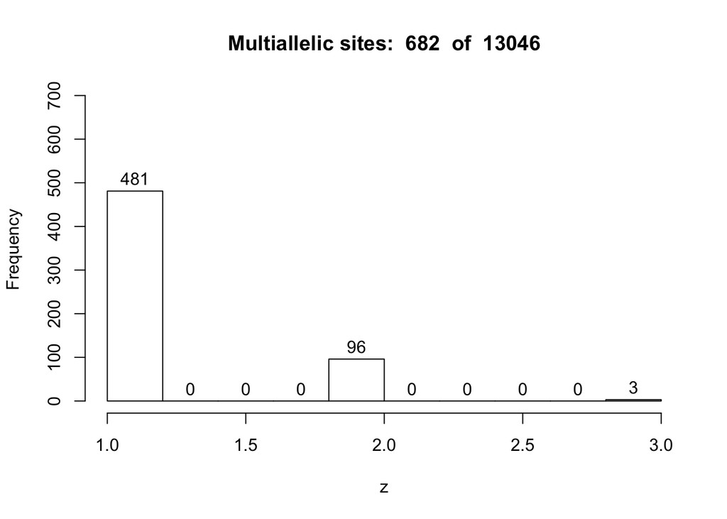

```r
hist(z, ylim=c(0, 1.2*length(z)), labels=TRUE,
     main=paste("Multiallelic sites: ", length(y), " of ", length(fixed.df$Multiallelic)))
```

```r
rm(x,y,z, Multiallelic)
```

# Split SIFT and Polyphen

```r
# Split SIFT
fixed.df <-
  fixed.df %>%
  mutate(SIFT_call=sub("\\(.*\\)","",SIFT)) %>%
  mutate(SIFT_score=as.numeric(
    sub(".*\\(","", sub("\\)","",SIFT)))) %>%
  select(-SIFT)

# Split PolyPhen
fixed.df <-
  fixed.df %>%
  mutate(PolyPhen_call=sub("\\(.*\\)","",PolyPhen)) %>%
  mutate(PolyPhen_score=as.numeric(
    sub(".*\\(","", sub("\\)","",PolyPhen)))) %>%
  select(-PolyPhen)
```

# update rownames

```r
# Generate row names
row_names <- fixed.df$SplitVarID
row_names[1:5]
```

```
## [1] "Var000000001" "Var000000002" "Var000000003" "Var000000004" "Var000000005"
```

```r
# Assign the rownames
row_names -> rownames(fixed.df)
row_names -> rownames(gt_add.mx)
row_names -> rownames(gt_num.mx)
row_names -> rownames(gt_chr.mx)
row_names -> rownames(dp.mx)
row_names -> rownames(gq.mx)
row_names -> rownames(ad.mx)
row_names -> rownames(ref.mx)
row_names -> rownames(alt.mx)

# Check
fixed.df[1:5,1:7]
```

```
##              CHROM     POS          ID REF ALT       QUAL FILTER
## Var000000001     1 3668950        <NA>   A   G   23805.04   PASS
## Var000000002     1 3669102 rs199579389   G   A    1057.45   PASS
## Var000000003     1 3669172  rs41315312   C   T 1167626.35   PASS
## Var000000004     1 3669201  rs10797410   A   G 8134730.17   PASS
## Var000000005     1 3669205  rs10910021   C   G 9502881.12   PASS
```

```r
gt_add.mx[1:5,6:10]
```

```
##              105_S337_L008 106_S303_L008 107_S467_L008 108_S482_L008 109_S484_L008
## Var000000001             0             0             0            NA             0
## Var000000002             0             0             0            NA             0
## Var000000003             0             0             0            NA             0
## Var000000004             2             1             1            NA             1
## Var000000005             2             1             1            NA             1
```

```r
alt.mx[1:5,6:10]
```

```
##              105_S337_L008 106_S303_L008 107_S467_L008 108_S482_L008 109_S484_L008
## Var000000001             0             0             0             0             0
## Var000000002             0             0             0             0             0
## Var000000003             0             0             0             0             0
## Var000000004           845           501           438             0           390
## Var000000005          1195           706           494             0           680
```

```r
# Clean-up
rm(row_names)
```

# Some common sense checks

```r
sum(fixed.df == "true", na.rm = T)
```

```
## [1] 0
```

```r
sum(fixed.df == "", na.rm = T)
```

```
## [1] 0
```

```r
sum(fixed.df == ".", na.rm = T)
```

```
## [1] 0
```

```r
colnames(fixed.df)
```

```
##   [1] "CHROM"                   "POS"                     "ID"                      "REF"                     "ALT"                     "QUAL"                    "FILTER"                  "init_AC"                 "init_AF"                 "init_AN"                 "AS_FilterStatus"         "AS_V…
##  [39] "exac_non_TCGA.AC_AMR"    "exac_non_TCGA.AC_Adj"    "exac_non_TCGA.AC_EAS"    "exac_non_TCGA.AC_FEMALE" "exac_non_TCGA.AC_FIN"    "exac_non_TCGA.AC_Hemi"   "exac_non_TCGA.AC_Het"    "exac_non_TCGA.AC_Hom"    "exac_non_TCGA.AC_MALE"   "exac_non_TCGA.AC_NFE"    "exac_non_TCGA.AC_OTH"    "exac…
##  [77] "exac_non_TCGA.Hom_AFR"   "exac_non_TCGA.Hom_AMR"   "exac_non_TCGA.Hom_EAS"   "exac_non_TCGA.Hom_FIN"   "exac_non_TCGA.Hom_NFE"   "exac_non_TCGA.Hom_OTH"   "exac_non_TCGA.Hom_SAS"   "kgen.AC"                 "kgen.AF"                 "kgen.AFR_AF"             "kgen.AMR_AF"             "kgen…
```

# save results

```r
save.image(paste(base_folder, "s01_read_vcf_to_r.RData", sep="/"))
```

# final section

```r
ls()
```

```
##  [1] "ad.mx"       "alt.mx"      "base_folder" "dp.mx"       "fixed.df"    "gq.mx"       "gt_add.mx"   "gt_chr.mx"   "gt_num.mx"   "meta.df"     "ref.mx"
```

```r
Sys.time()
```

```
## [1] "2019-09-20 15:52:03 BST"
```